# Homework 4

Group Names: Polina Semenova, Michael Moore, Kateryna Mykhaylova  
Git repo: https://github.com/psemenova/DS202

Loading in the Data

```r
choco = read.csv("https://ds202-at-isu.github.io/labs/data/choco.csv")
```

## Question Set 1

1. What is the overall number of chocolate bars rated?  
   **Answer: 1852 number of chocolate bars rated**

```r
str(choco)
```

```
## 'data.frame':    1852 obs. of  9 variables:
##  $ Company             : chr  "A. Morin" "A. Morin" "A. Morin" "A. Morin" ...
##  $ Specific.Bean.Origin: chr  "Agua Grande" "Kpime" "Panama" "Madagascar" ...
##  $ REF                 : int  1876 1676 1011 1011 1011 1011 1015 1015 1015 1015 ...
##  $ Review.Date         : int  2016 2015 2013 2013 2013 2013 2013 2013 2013 2013 ...
##  $ Cocoa.Pct           : num  63 70 70 70 70 70 70 70 70 70 ...
##  $ Company.Location    : chr  "France" "France" "France" "France" ...
##  $ Rating              : num  3.75 2.75 2.75 3 3.25 3.75 2.75 3 3.25 4 ...
##  $ Bean.Type           : chr  "" "" "" "Criollo" ...
##  $ Broad.Bean.Origin   : chr  "Sao Tome" "Togo" "Panama" "Madagascar" ...
```

2. How does the number of ratings depend on the year? Draw a bar chart of the number of reports  
   **Answer: More got rated as the years went on until 2015 where it peaked. 2016 was lower and 2017 even lower. While the rise from 2006 to 2015 was not exactly linear it still looks like it has a big enough correlation to consider that there is an linera trend up until the peak.**

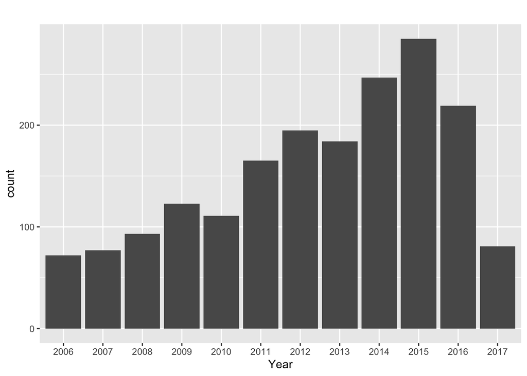

```r
choco %>% ggplot(aes(x = as.factor(Review.Date))) +
  geom_bar() +
  ggtitle("") +
  xlab("Year")
```

## Question Set 2

1. How are ratings distributed? Draw a histogram of ratings and describe it. Don’t forget to mention outlines, if there are any.  
   **Answer: The ratings seem to follow a simple normal distribution centered at 3.25 and extends to 2.5 and 4. I do not think that any rating below 2.5 or above 4 could be considered part of this distribution. This claim is backed up by the fact that anything under or equal to 2 and any 5 value is considered to be an outlier.**

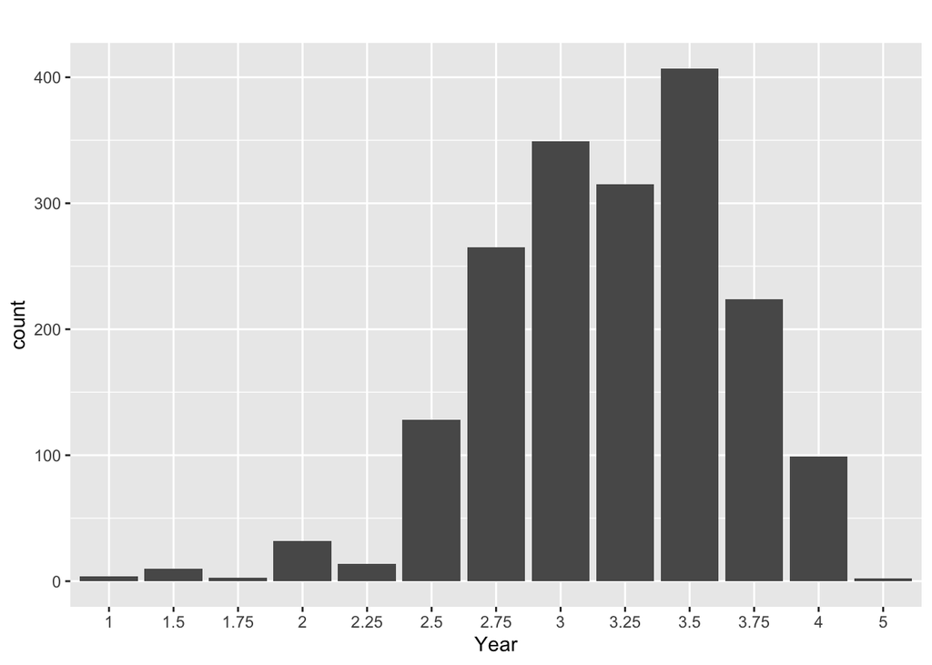

```r
choco %>% ggplot(aes(x = as.factor(Rating))) +
  geom_bar() +
  ggtitle("") +
  xlab("Year")
```

```r
boxplot.stats(choco$Rating)$out
```

```
##  [1] 5.00 5.00 1.75 1.75 1.50 1.50 2.00 2.00 1.50 1.00 2.00 1.00 1.50 1.00 1.50
## [16] 2.00 2.00 2.00 2.00 2.00 1.75 2.00 2.00 2.00 1.50 2.00 2.00 2.00 2.00 2.00
## [31] 1.50 2.00 1.00 2.00 2.00 2.00 2.00 2.00 1.50 2.00 2.00 2.00 2.00 2.00 1.50
## [46] 2.00 2.00 2.00 1.50 2.00 2.00
```

2. Do ratings depend on the cocoa percentage of a chocolate bar?  
   **Answer: There is no correlation between rating and cocoa percentage. And as you can see the correlation value is -0.16.**

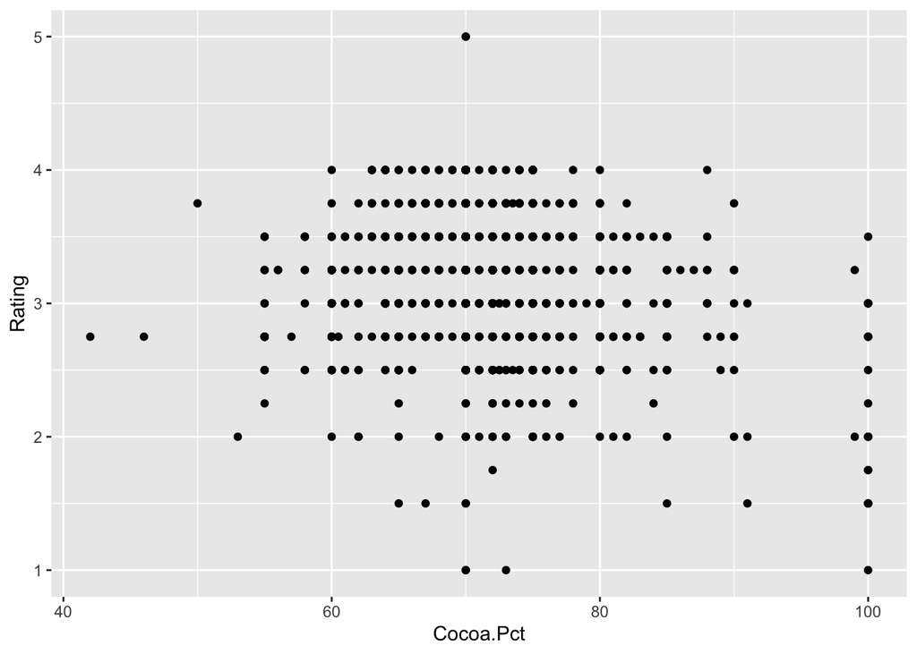

```r
choco %>% ggplot(aes(x = Cocoa.Pct, y = Rating)) +
  geom_point()
```

```r
data1 <- choco[, c(5, 7)]
round(cor(data1), 2)
```

```
##           Cocoa.Pct Rating
## Cocoa.Pct      1.00  -0.16
## Rating        -0.16   1.00
```

3. How do ratings compare across different company locations? Focus on the three locations with the most ratings:  
   **Answer: As we can see, America makes the most chocolate with Canada and France far behind. However, as we can barely see, the average rating for Canada and France is higher than for America. These observations are backed up by the data show by the 6 lines below the plot. It shows America’s amount being more than double Canada and France combined, but the avergae being worse than both.**

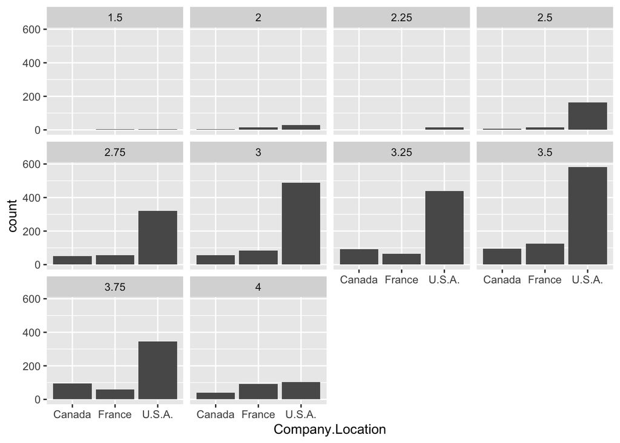

```r
choco1 <- dplyr::filter(choco, Company.Location %in% c("U.S.A.","France", "Canada"))
choco2 <- dplyr::filter(choco, Company.Location %in% c("U.S.A."))
choco3 <- dplyr::filter(choco, Company.Location %in% c("Canada"))
choco4 <- dplyr::filter(choco, Company.Location %in% c("France"))

ggplot(data = choco1, aes(x = Company.Location)) +
  geom_bar(aes(weight = Rating), position = position_dodge()) +
  facet_wrap(~Rating)
```

```r
str(choco2) # USA  - 787
```

```
## 'data.frame':    787 obs. of  9 variables:
##  $ Company             : chr  "Acalli" "Acalli" "Altus aka Cao Artisan" "Altus aka Cao Artisan" ...
##  $ Specific.Bean.Origin: chr  "Chulucanas, El Platanal" "Tumbes, Norandino" "Momotombo" "Acopagro" ...
##  $ REF                 : int  1462 1470 1728 1728 1732 1732 1732 1125 1125 1129 ...
##  $ Review.Date         : int  2015 2015 2016 2016 2016 2016 2016 2013 2013 2013 ...
##  $ Cocoa.Pct           : num  70 70 60 60 60 60 60 60 60 80 ...
##  $ Company.Location    : chr  "U.S.A." "U.S.A." "U.S.A." "U.S.A." ...
##  $ Rating              : num  3.75 3.75 2.75 3 2.5 2.5 2.75 2.5 3 3.25 ...
##  $ Bean.Type           : chr  "" "Criollo" "" "" ...
##  $ Broad.Bean.Origin   : chr  "Peru" "Peru" "Nicaragua" "Peru" ...
```

```r
str(choco3) # Canada - 132
```

```
## 'data.frame':    132 obs. of  9 variables:
##  $ Company             : chr  "Ambrosia" "Ambrosia" "Ambrosia" "Ambrosia" ...
##  $ Specific.Bean.Origin: chr  "Belize" "Madagascar" "Dominican Republic" "Papua New Guinea" ...
##  $ REF                 : int  1494 1494 1498 1498 1498 1498 1426 1219 682 377 ...
##  $ Review.Date         : int  2015 2015 2015 2015 2015 2015 2014 2014 2011 2009 ...
##  $ Cocoa.Pct           : num  64 66 75 63 70 68 70 70 65 80 ...
##  $ Company.Location    : chr  "Canada" "Canada" "Canada" "Canada" ...
##  $ Rating              : num  3 3.25 3.25 3.25 3.25 3.5 2.75 2.5 3.25 2.5 ...
##  $ Bean.Type           : chr  "Trinitario" "Trinitario" "" "" ...
##  $ Broad.Bean.Origin   : chr  "Belize" "Madagascar" "Dominican Republic" "Papua New Guinea" ...
```

```r
str(choco4) # France - 158
```

```
## 'data.frame':    158 obs. of  9 variables:
##  $ Company             : chr  "A. Morin" "A. Morin" "A. Morin" "A. Morin" ...
##  $ Specific.Bean.Origin: chr  "Agua Grande" "Kpime" "Panama" "Madagascar" ...
##  $ REF                 : int  1876 1676 1011 1011 1011 1011 1015 1015 1015 1015 ...
##  $ Review.Date         : int  2016 2015 2013 2013 2013 2013 2013 2013 2013 2013 ...
##  $ Cocoa.Pct           : num  63 70 70 70 70 70 70 70 70 70 ...
##  $ Company.Location    : chr  "France" "France" "France" "France" ...
##  $ Rating              : num  3.75 2.75 2.75 3 3.25 3.75 2.75 3 3.25 4 ...
##  $ Bean.Type           : chr  "" "" "" "Criollo" ...
##  $ Broad.Bean.Origin   : chr  "Sao Tome" "Togo" "Panama" "Madagascar" ...
```

```r
mean(choco2$Rating)
```

```
## [1] 3.162325
```

```r
mean(choco3$Rating)
```

```
## [1] 3.3125
```

```r
mean(choco4$Rating)
```

```
## [1] 3.253165
```

## Your Own Question

1. Which country has the highest rated chocolate on average?  
   **Answer: From the chart we can clearly see that Chile has the highest rated chocolate on average. We can also see that Chile has the highest based on the 1 line of code. We can also see that the average rating is consistent across countries at ~3.**

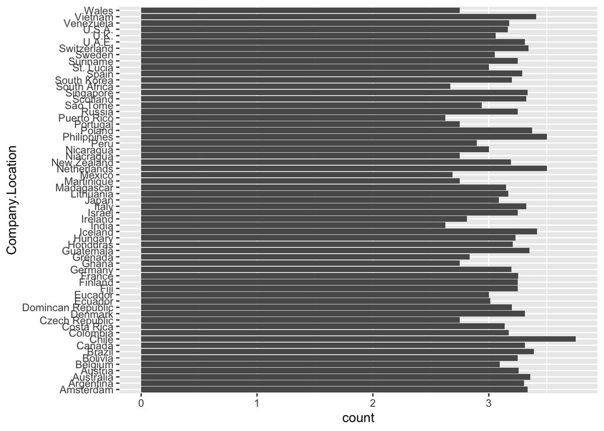

```r
data2 <- ddply(choco, .(Company.Location), function(x) mean(x$Rating))
names(data2)[2] <- 'AverageRating'

data2 %>% ggplot(aes(x = Company.Location)) +
  geom_bar(aes(weight = AverageRating)) +
  coord_flip()
```

```r
data2[which.max(data2$AverageRating),]
```

```
##   Company.Location AverageRating
## 9            Chile          3.75
```

## Summary of Workflow

Worked together on the same computer at the library on this homework assignment. Took turns writing out the code on the same computer.